# data609hw8

jim lung

October 18, 2018

## Section 9.1, Problem 4

There are only two possible outcomes, so the probability of failure is $P(f) = 1 - P(s) = 3/5$. Thus,
$$E = w_sp_s + w_fp_f = \frac{2}{5} \times 55000 + \frac{3}{5} \times (-1750) = 20950$$

## Section 9.1, Problem 6

The expected values of the two policies are based on the temperature and the profits:
$$\begin{aligned}
E(cola) &= 0.3 \times 1500 + 0.7 \times 5000 = 3950\\
E(coffee) &= 0.3 \times 4000 + 0.7 \times 1000 = 1900
\end{aligned}$$
The expected value of selling cola is higher; therefore the firm should purchase cola. This makes intuitive sense, as cola has a higher profit under the more likely weather scenario. This is further illustrated in the decistion tree below.

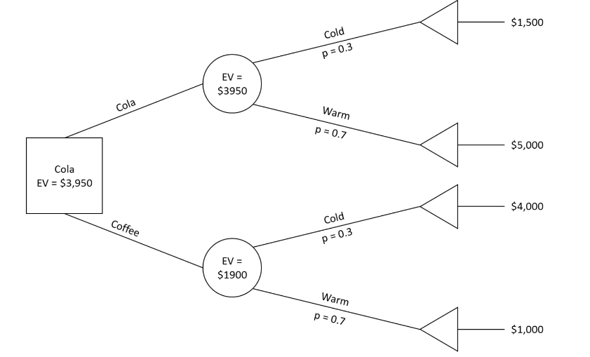

## Section 9.2, Problem 3

Basedon the on the decision tree presented below, the resort should be operated. This decision has an expected value of $116,000.

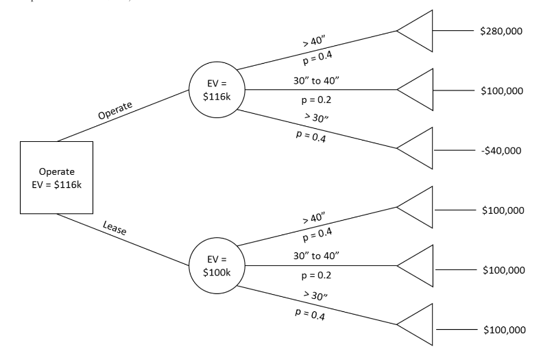

## Section 9.3, Problem 3

If oil is found, the net profit is $6M - $1M = $5M. If no oil is found, a -$1M net profit (i.e. a $1M loss) is realized. If a geologist is hired to perform testing, each of these profit numbers is lowered by $0.1M (resulting in a $4.9M profit and $1.1M loss). This information is reflected in teh decision tree below:

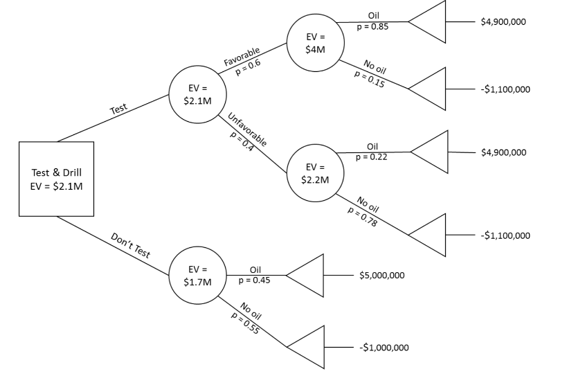

As indicated in the decision tree, the oil company should hire a geologist to perform testing. It is indicated that they should drill – this is because the expected value (profit) is greater than 0.

## Section 9.4, Problem 1

### Part a

The expected values are given by $\sum w_ip_i$ for the table:
$$\begin{aligned}
E(A) &= 0.35 \times 1100 + 0.3 \times 900 + 0.25 \times 400 + 0.1 \times 300 = 785\\
E(B) &= 0.35 \times 850 + 0.3 \times 1500 + 0.25 \times 1000 + 0.1 \times 500 = 1047.50\\
E(A) &= 0.35 \times 700 + 0.3 \times 1200 + 0.25 \times 500 + 0.1 \times 900 = 820
\end{aligned}$$

The highest expected value is for alternative B, so that should be chosen if the criteria is maximized expected value.

### Part b

The regret table is composed by selecting each entry from the column maximum to get the regret under each state of nature. The expected regret is then calculated by $\sum r_ip_i$:

```r
# enter payoffs and probabilities
X <- matrix(
  c(1100,  900,  400, 300,
     850, 1500, 1000, 500,
     700, 1200,  500, 900),
  nrow = 3, byrow = TRUE)
p <- c(0.35, 0.3, 0.25, 0.1)
# get regret matrix
reg <- apply(X, 2, function(x) {max(x) - x})
# calculate expected regrets
reg <- cbind(reg, apply(reg, 1, function(x) {sum(x * p)}))
```

|  | 1 | 2 | 3 | 4 | Expected Regret |
| --- | --- | --- | --- | --- | --- |
| **A** | 0 | 600 | 600 | 600 | 390 |
| **B** | 250 | 0 | 0 | 400 | 127.5 |
| **C** | 400 | 300 | 500 | 0 | 355 |

The lowest expected regret occurs for alternative B, so this should also be selected if the criteria is minimized expected regret.